# Homework for 7 I 2016

Michał Frej

## Wykres czasu reakcji i liczby dni dla każdego kierowcy.

Zacznijmy od obejrzenia danych.

```r
library(lme4)
library(lattice)
head(sleepstudy)
```

```
##   Reaction Days Subject
## 1 249.5600    0     308
## 2 258.7047    1     308
## 3 250.8006    2     308
## 4 321.4398    3     308
## 5 356.8519    4     308
## 6 414.6901    5     308
```

```r
dim(sleepstudy)
```

```
## [1] 180   3
```

```r
summary(sleepstudy)
```

```
##     Reaction          Days        Subject
##  Min.   :194.3   Min.   :0.0   308    : 10
##  1st Qu.:255.4   1st Qu.:2.0   309    : 10
##  Median :288.7   Median :4.5   310    : 10
##  Mean   :298.5   Mean   :4.5   330    : 10
##  3rd Qu.:336.8   3rd Qu.:7.0   331    : 10
##  Max.   :466.4   Max.   :9.0   332    : 10
##                                (Other):120
```

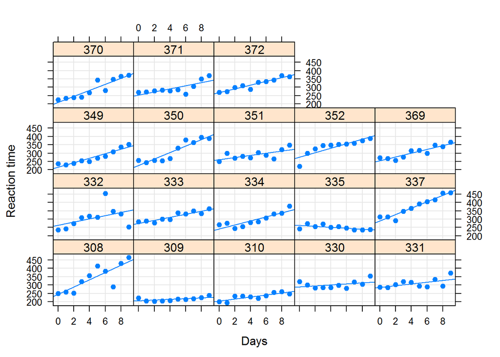

```r
xyplot(Reaction ~ Days | Subject,sleepstudy, type = c("g","p","r"),
  xlab = "Days", ylab = "Reaction time", pch=19)
```

## Model opisujący liniowy trend między czasem reakcji i liczbą dni.

Wykresy dla poszczególnych kierowców są z dobrą dokładnością przybliżone funkcjami liniowymi, więc nie ma powodu, by szukać przybliżej w klasie wielomianów wyższego stopnia. Aby uniknąć korelacji między wyrazem wolnym a współczynnikiem nachylenia(łatwiej obliczymy kwantyle rozkładu tych współczynników) zdecydowałem się na poniższy model

```r
model = lmer(Reaction ~ Days +  (Days-1|Subject) + (1|Subject), data=sleepstudy, REML=FALSE)
summary(model)
```

```
## Linear mixed model fit by maximum likelihood  ['lmerMod']
## Formula: Reaction ~ Days + (Days - 1 | Subject) + (1 | Subject)
##    Data: sleepstudy
##
##      AIC      BIC   logLik deviance df.resid
##     1762     1778     -876     1752      175
##
## Scaled residuals:
##     Min      1Q  Median      3Q     Max
## -3.9535 -0.4673  0.0239  0.4625  5.1883
##
## Random effects:
##  Groups    Name        Variance Std.Dev.
##  Subject   Days         33.63    5.799
##  Subject.1 (Intercept) 584.25   24.171
##  Residual              653.12   25.556
## Number of obs: 180, groups:  Subject, 18
##
## Fixed effects:
##             Estimate Std. Error t value
## (Intercept)  251.405      6.708   37.48
## Days          10.467      1.519    6.89
##
## Correlation of Fixed Effects:
##      (Intr)
## Days -0.194
```

Niestety nasz model jest obarczony sporym błędem predykcjio czym świadczą wariancje wyrazu wolnego i reszt modelu.

Sprawdźmy czy model jest sensowny testując reszty,

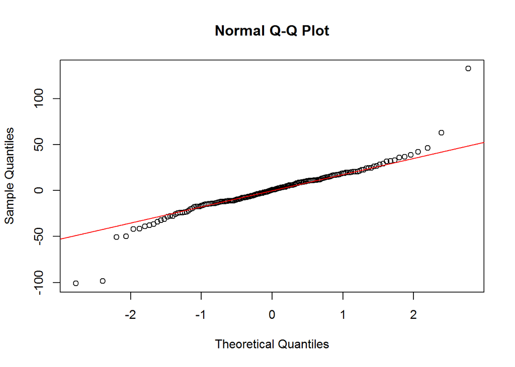

```r
reszty <- sleepstudy$Reaction - fitted.values(model)
qqnorm(reszty)
qqline(reszty,col="red")
```

istotność efektów stałych

```r
tStat <- summary(model)$coeff[,3]
pValues <- sapply(1:length(tStat),function(i) {2*pnorm(abs(tStat[i]),lower.tail = F)})
pValues
```

```
##   (Intercept)          Days
## 1.934294e-307  5.599692e-12
```

oraz sens dodawania efektu losowego złożonego z aż dwóch składników.

```r
model2 = lmer(Reaction ~ Days +  (Days-1|Subject) , data=sleepstudy, REML=FALSE)
model3 = lmer(Reaction ~ Days +  (1|Subject) , data=sleepstudy, REML=FALSE)
anova(model2,model)
```

```
## Data: sleepstudy
## Models:
## model2: Reaction ~ Days + (Days - 1 | Subject)
## model: Reaction ~ Days + (Days - 1 | Subject) + (1 | Subject)
##        Df    AIC    BIC  logLik deviance  Chisq Chi Df Pr(>Chisq)
## model2  4 1782.1 1794.8 -887.04   1774.1
## model   5 1762.0 1778.0 -876.00   1752.0 22.077      1  2.619e-06 ***
## ---
## Signif. codes:  0 '***' 0.001 '**' 0.01 '*' 0.05 '.' 0.1 ' ' 1
```

```r
anova(model3,model)
```

```
## Data: sleepstudy
## Models:
## model3: Reaction ~ Days + (1 | Subject)
## model: Reaction ~ Days + (Days - 1 | Subject) + (1 | Subject)
##        Df    AIC    BIC  logLik deviance  Chisq Chi Df Pr(>Chisq)
## model3  4 1802.1 1814.8 -897.04   1794.1
## model   5 1762.0 1778.0 -876.00   1752.0 42.075      1  8.782e-11 ***
## ---
## Signif. codes:  0 '***' 0.001 '**' 0.01 '*' 0.05 '.' 0.1 ' ' 1
```

QQplot nie wygląda źle, a wszystkie p-wartości są bardzo małe, więc każdy element naszego modelu wnosi coś istotnego. Nie ma więc powodu, by zrezygnować z tego modelu.

## Trendy dla poszczególnych kierowców.

```r
rnd <- data.frame(t(fixef(model)+t(ranef(model)$Subject)))
names(rnd) <- c("Intercept","Slope")
rnd
```

```
##     Intercept      Slope
## 308  260.6415  12.321942
## 309  242.7876 -29.555020
## 310  245.9707 -28.255876
## 330  246.5469  34.370604
## 331  248.3003  32.863607
## 332  251.1229  19.519287
## 333  251.1641  27.318509
## 334  252.4914   3.187093
## 335  240.6069  10.605830
## 337  260.0366  44.980672
## 349  252.6082 -14.795815
## 350  258.0606  -2.893934
## 351  248.3724  15.177821
## 352  254.9360  31.176770
## 369  252.2779  13.704618
## 370  256.2733 -15.358871
## 371  250.4119  11.317774
## 372  252.6827  22.726137
```

Wyestymowane współczynniki wychodzą dość dziwne biorąc pod uwagę wyraźny trend wzrostowy na wszystkich poza jednym wykresie. Jest to spowodowane dużą wariancją błędu, o czym już wspominaliśmy.

## Rozkłady współczynników trendu.

Statystyki dla wyrazu wolnego i współczynnika nachylenia prezentują się następująco:

```r
sdGeneral <- attributes(unclass(VarCorr(model))$Subject)$stddev
kwantyl <- function(poziom,id,wsp){
      #wsp=1 oznacza wyraz wolny, wsp=2 współczynnik nachylenia prostej
      m <-model.matrix(model)[id,wsp]*fixef(model)[wsp]
      qnorm(poziom,mean = m, sd= sdGeneral)
}
interceptSummary <- data.frame(A=kwantyl(0.25,1,1),B=kwantyl(0.5,1,1),C=kwantyl(0.75,1,1))
names(interceptSummary) <- c("1Q","median","3Q")
interceptSummary
```

```
##         1Q   median       3Q
## 1 247.4935 251.4051 255.3167
```

```r
slopeSummary <- data.frame(A=kwantyl(0.25,2,2),B=kwantyl(0.5,2,2),C=kwantyl(0.75,2,2))
names(slopeSummary) <- c("1Q","median","3Q")
slopeSummary
```

```
##         1Q   median       3Q
## 1 6.555644 10.46729 14.37893
```

Oba rozkłady zgadzają się z rysunkami, którew zdecydowanej większości ukazują rosnący czas reakcji kierowcy, który nie przespał kilku nocy z rzędu.